# Analysis of a binary image

This tutorial explains how to analyze a 2D binary image by persistent homology. You learn the following topics in this tutorial.

1. How to compute a PD (Persistence Diagram) from a image
2. How to visualize the PD
3. How to output birth-death pairs in the text format
4. How to apply basic inverse analysis called birth pixels and death pixels
5. How to use high-level inverse analysis called optimal volume

The PD is computed from a filtration constructed by signed distance transform. This means that the black area in the binary image is shrinked and expanded and HomCloud captures the information of the appearance and disappearance of connected components and holes. Please see Section 2.3 in https://arxiv.org/abs/1706.10082 .

## How to compute a PD

The example image file is `binary-image.png`. First, we display the image.

```python
# Load a module for displaying an image
# IPython package has some useful modules for jupyter notebook
# and import a function "display" and a class "Image" for displaying a image
from IPython.display import display, Image
```

```python
%matplotlib inline
```

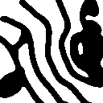

```python
display(Image("binary-image.png"))
```

`imageio` library is used to load the image.

```python
# Import imageio library
import imageio
```

Load the image. This image have R, G, B components and we read the data as grayscale data `mode="L"`.

```python
image = imageio.v3.imread("binary-image.png", mode="L")
```

Now we show the histogram of pixel values.

```python
import matplotlib.pyplot as plt
import numpy as np
```

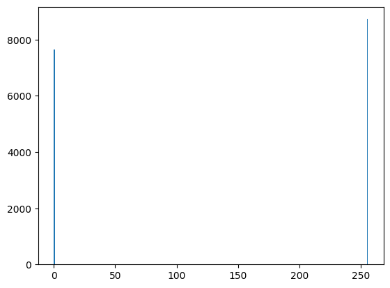

```python
plt.hist(np.ravel(image), range=(0,256), bins=256); None
```

The pixel values are 0 or 255. That means that the image is already binarized. HomCloud accepts a boolean array as a binary image, we need to convert `image` into a boolean array. numpy's comparison operators make such a booelan array. We use 128 as the threshold for binarization. In this tutorial, we will focus on the black area, so `image < 128` is used.

```python
binary_image = image < 128
```

Now PD is computed.

```python
# Load HomCloud library. "hc" is an alias of hocmloud.interface
import homcloud.interface as hc
```

```python
hc.PDList.from_bitmap_levelset(hc.distance_transform(binary_image, signed=True), save_to="binary-image.pdgm")
```

```
PDList(path=binary-image.pdgm)
```

The following code load the file.

```python
pdlist = hc.PDList("binary-image.pdgm")
```

## How to visualize a PD

Next, we visualize the 0th PD. We investigate the black connected components in the input image.

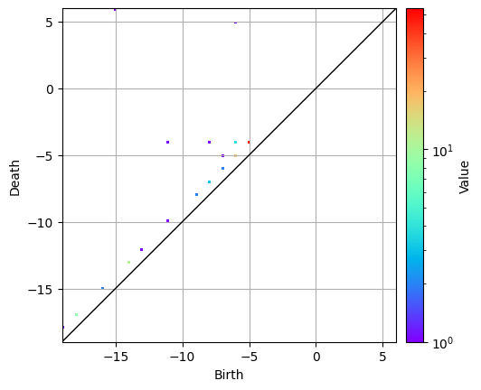

```python
pdlist.dth_diagram(0).histogram().plot(colorbar={"type":"log"})
```

`pdlist` has the PDs of all degree, we get the 0th PD by `dth_diagram(0)`, construct a 2D histogram by `.histogram()`, and plot the histogram by `.plot(...)`. We specify the colorbar spec by `colorbar={"type":"log"}`, this means that log-scale colorbar is used. This is the same way as a pointcloud.

Some small points appear in the figure. In fact, we use the manhattan distance for the computation and all birth times and death times are integer values for that reason. Therefore the resolution is too fine for the visualization. Now we adjust the resolution. The arguments `x_range=(-20.5, 7.5), x_bins=28` change the range and the number of bins. The size of each bin is adjusted to 1x1 and the center of each bin is adjusted to an integer point.

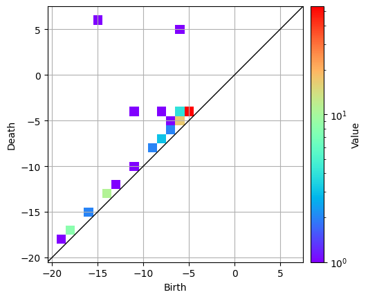

```python
pdlist.dth_diagram(0).histogram(x_range=(-20.5, 7.5), x_bins=28).plot(colorbar={"type":"log"})
```

Since the `y_range` and `y_bins` arguments are not given, the range and the number of bins in y-axis are set as same as x-axis.

To save the figure into a file, `savefig` method in `matplotlib` is available.

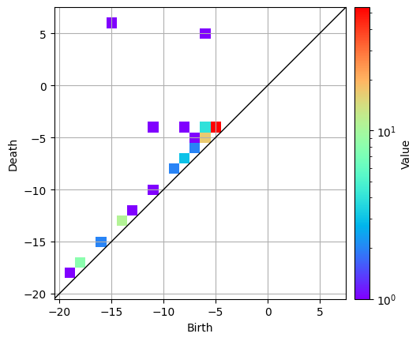

```python
pdlist.dth_diagram(0).histogram(x_range=(-20.5, 7.5), x_bins=28).plot(colorbar={"type":"log"})
plt.savefig("binary-image-pd0.png")
```

## Inverse analysis (birth pixels and death pixels)

You can see the birth times and death times by attribtues `births` and `deaths`.

```python
pd = pdlist.dth_diagram(0)
pd.births, pd.deaths
```

```
(array([-19., -18., -18., -18., -18., -18., -18., -18., -18., -16., -16.,
        -14., -14., -14., -14., -14., -14., -14., -14., -14., -14., -14.,
        -13., -11.,  -9.,  -9.,  -8.,  -8.,  -8.,  -7.,  -7.,  -6.,  -6.,
         -6.,  -6.,  -6.,  -6.,  -6.,  -6.,  -6.,  -6.,  -6.,  -6.,  -6.,
         -6.,  -6.,  -7.,  -6.,  -6.,  -5.,  -5.,  -5.,  -5.,  -5.,  -5.,
         -5.,  -6.,  -5., -11.,  -5.,  -5.,  -5.,  -5.,  -5.,  -5.,  -5.,
         -5.,  -5.,  -5.,  -5.,  -5.,  -8.,  -5.,  -5.,  -5.,  -5.,  -5.,
         -5.,  -5.,  -5.,  -5.,  -5.,  -5.,  -6.,  -5.,  -5.,  -5.,  -5.,
         -5.,  -5.,  -5.,  -5.,  -5.,  -5.,  -5.,  -5.,  -5.,  -5.,  -5.,
         -5.,  -5.,  -5.,  -5.,  -5.,  -5.,  -6.,  -6.,  -5.,  -5.,  -6.,
        -15.]),
 array([-18., -17., -17., -17., -17., -17., -17., -17., -17., -15., -15.,
        -13., -13., -13., -13., -13., -13., -13., -13., -13., -13., -13.,
        -12., -10.,  -8.,  -8.,  -7.,  -7.,  -7.,  -6.,  -6.,  -5.,  -5.,
         -5.,  -5.,  -5.,  -5.,  -5.,  -5.,  -5.,  -5.,  -5.,  -5.,  -5.,
         -5.,  -5.,  -5.,  -5.,  -5.,  -4.,  -4.,  -4.,  -4.,  -4.,  -4.,
         -4.,  -4.,  -4.,  -4.,  -4.,  -4.,  -4.,  -4.,  -4.,  -4.,  -4.,
         -4.,  -4.,  -4.,  -4.,  -4.,  -4.,  -4.,  -4.,  -4.,  -4.,  -4.,
         -4.,  -4.,  -4.,  -4.,  -4.,  -4.,  -4.,  -4.,  -4.,  -4.,  -4.,
         -4.,  -4.,  -4.,  -4.,  -4.,  -4.,  -4.,  -4.,  -4.,  -4.,  -4.,
         -4.,  -4.,  -4.,  -4.,  -4.,  -4.,  -4.,  -4.,  -4.,  -4.,   5.,
          6.]))
```

From the above PD, you see that many birth-death pairs are concentrated at (-5, -4). Now we try to analyze these pairs. We use birth pixels and death pixels. Please see Section 2.3 in https://arxiv.org/abs/1706.10082 . In this paper, birth/death pixels are called birth/death positions.

In HomCloud, we get birth positions by `birth_positions` attribute.

```python
pd.birth_positions
```

```
[[57, 121],
 [47, 112],
 [48, 113],
 [49, 114],
 [50, 115],
 [51, 116],
 [52, 117],
 [53, 118],
 [46, 111],
 [73, 111],
 [74, 110],
 [40, 112],
 [83, 113],
 [84, 114],
 [85, 115],
```

[output cut: 96 more lines]

We also can get death positions by `pd.death_positions`.

Please note that each coordinate is ordered by (y, x). This is because numpy's indexing rule.

The above attributes have the array of birth times, the array of death times, the array of birth positions, and the array of death positions. You sometimes want an object that has birth and death times and birth and death positions. `hc.Pair` class holds the information. `pd.pairs()` returns the list of `Pair` objects.

```python
pairs = pd.pairs()
```

```python
pairs[0].birth_time(), pairs[0].death_time()
```

```
(-19.0, -18.0)
```

```python
pairs[0].birth_position
```

```
[57, 121]
```

```python
pairs[0].death_position
```

```
[56, 121]
```

Now we select all (-5, -4) pairs from the list. Python's list comprehension expression is useful for that purpose.

```python
pairs_m5_m4 = [pair for pair in pairs if pair.birth_time() == -5 and pair.death_time() == -4]
```

```python
pairs_m5_m4
```

```
[Pair(-5.0, -4.0),
 Pair(-5.0, -4.0),
 Pair(-5.0, -4.0),
 Pair(-5.0, -4.0),
 Pair(-5.0, -4.0),
 Pair(-5.0, -4.0),
 Pair(-5.0, -4.0),
 Pair(-5.0, -4.0),
 Pair(-5.0, -4.0),
 Pair(-5.0, -4.0),
 Pair(-5.0, -4.0),
 Pair(-5.0, -4.0),
 Pair(-5.0, -4.0),
 Pair(-5.0, -4.0),
 Pair(-5.0, -4.0),
 Pair(-5.0, -4.0),
 Pair(-5.0, -4.0),
 Pair(-5.0, -4.0),
 Pair(-5.0, -4.0),
 Pair(-5.0, -4.0),
 Pair(-5.0, -4.0),
 Pair(-5.0, -4.0),
 Pair(-5.0, -4.0),
 Pair(-5.0, -4.0),
 Pair(-5.0, -4.0),
 Pair(-5.0, -4.0),
 Pair(-5.0, -4.0),
 Pair(-5.0, -4.0),
 Pair(-5.0, -4.0),
 Pair(-5.0, -4.0),
 Pair(-5.0, -4.0),
 Pair(-5.0, -4.0),
 Pair(-5.0, -4.0),
 Pair(-5.0, -4.0),
 Pair(-5.0, -4.0),
 Pair(-5.0, -4.0),
 Pair(-5.0, -4.0),
 Pair(-5.0, -4.0),
 Pair(-5.0, -4.0),
 Pair(-5.0, -4.0),
 Pair(-5.0, -4.0),
 Pair(-5.0, -4.0),
 Pair(-5.0, -4.0),
 Pair(-5.0, -4.0),
 Pair(-5.0, -4.0),
 Pair(-5.0, -4.0),
 Pair(-5.0, -4.0),
 Pair(-5.0, -4.0),
 Pair(-5.0, -4.0),
 Pair(-5.0, -4.0),
 Pair(-5.0, -4.0),
 Pair(-5.0, -4.0),
 Pair(-5.0, -4.0),
 Pair(-5.0, -4.0)]
```

Looks good. We plot birth positions of these birth-death pairs on the input image. `draw_birthdeath_pixels_2d` is available for the purpose.

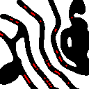

```python
birth_pixels_image = hc.draw_birthdeath_pixels_2d(
    pairs_m5_m4, "binary-image.png", draw_birth=True
)
display(birth_pixels_image)
```

The first argument is the list of plotted pairs, the second argument is the background image. `draw_birth=True` is given to draw birth pixels. If you want to draw death pixels, please give the argument `draw_death=True` .

Red points are drawn on the black roads. This means that the (-5, -4) pairs correspond to this black road shapes.

## Advanced invese analysis

Each pair in 0th PD corresponds a connected component (an island), but the death pixel of the pair can only visualize one pixel in the island. Although the birth/death pixels are easy to use and their computation cost is quite cheap, the information is a little. We want to see the islands themselves. The regions are called *volumes* in this tutorial and we can compute volumes by using HomCloud.

`BitmapPHTrees` class is available. The following python code computes the information.

```python
hc.BitmapPHTrees.for_bitmap_levelset(hc.distance_transform(binary_image, signed=True), save_to="binary-image-tree.pdgm")
```

```
PDList(path=binary-image-tree.pdgm)
```

The data is loaded as follows.

```python
phtrees = hc.PDList("binary-image-tree.pdgm").bitmap_phtrees(0)
```

In this object (this is an instance of `BitmapPHTrees` class), the infomation is represented by trees and all birth-death pairs are represented by tree nodes. By `pair_nodes_in_rectangle` method we get all nodes corresponding to (-5, -4).

```python
nodes = phtrees.pair_nodes_in_rectangle(-5, -5, -4, -4)
```

The nodes are visualized by `draw_volumes_on_2d_image`.

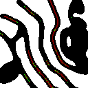

```python
hc.draw_volumes_on_2d_image(nodes, "binary-image.png", color=(255, 0, 0), alpha=0.5,
                            birth_position=(0, 255, 0))
```

The volumes are drawn in red, and birth positions are drawn by green.

The tutorial ends here. Thank you for your attention.